# Danish Kings

Zaid Khalaf

2025-03-05

# Load necessary libraries

```r
library(tidyverse)
```

# Load the dataset with correct tidyverse function (assuming semicolon separator)

# Inspect the data

The task here is to load your Danish Monarchs csv into R using the `tidyverse` toolkit, calculate and explore the kings’ duration of reign with pipes `%>%` in `dplyr` and plot it over time.

## Load the kings

Make sure to first create an `.Rproj` workspace with a `data/` folder where you place either your own dataset or the provided `kings.csv` dataset.

1. Look at the dataset that are you loading and check what its columns are separated by? (hint: open it in plain text editor to see)

2. Create a `kings` object in R with the different functions below and inspect the different outputs.
- `read.csv()`
- `read_csv()`
- `read.csv2()`
- `read_csv2()`

```r
kings1 <- read.csv("data/DANSKKONGE.csv")

kings2 <- read_csv("data/DANSKKONGE.csv")
kings3 <- read.csv2("data/DANSKKONGE.csv")

kings4 <- read_csv2( "data/DANSKKONGE.csv",na="-")
```

```
## ℹ Using "','" as decimal and "'.'" as grouping mark. Use `read_delim()` for more control.
```

Answer: 1. Which of these functions is a `tidyverse` function? Read data with it below into a `kings` object # tidyverse function is the one with the underscore: kings4 <- read_csv2 2. What is the result of running `class()` on the `kings` object created with a tidyverse function. # when you run the clas()´columns are created with the differnt king datasets 3. How many columns does the object have when created with these different functions? # There is 5 columns 4. Show the dataset so that we can see how R interprets each column i will do it below.

```r
# COMPLETE THE BLANKS BELOW WITH YOUR CODE, then turn the 'eval' flag in this chunk to TRUE.



class(kings1)
```

```
## [1] "data.frame"
```

```r
class(kings4)
```

```
## [1] "spec_tbl_df" "tbl_df"      "tbl"         "data.frame"
```

```r
glimpse(kings4)
```

```
## Rows: 58
## Columns: 5
## $ Name          <chr> "Gorm den Gamle", "Harald Blaatand", "Svend Tveskaeg", "…
## $ `Birth Year`  <chr> "ca_900", "ca_958", "ca_960", "995", "1018", "1024", "10…
## $ `Death Year`  <chr> "ca_958", "ca_986", "1014", "1035", "1042", "1047", "107…
## $ `Reign Start` <dbl> 936, 958, 986, 1018, 1035, 1042, 1047, 1076, 1080, 1086,…
## $ `Reign End`   <dbl> 958, 986, 1014, 1035, 1042, 1047, 1076, 1080, 1086, 1095…
```

## Calculate the duration of reign for all the kings in your table

You can calculate the duration of reign in years with `mutate` function by subtracting the equivalents of your `startReign` from `endReign` columns and writing the result to a new column called `duration`. But first you need to check a few things:

- Is your data messy? Fix it before re-importing to R
- Do your start and end of reign columns contain NAs? Choose the right strategy to deal with them: `na.omit()`, `na.rm=TRUE`, `!is.na()`

Create a new column called `duration` in the kings dataset, utilizing the `mutate()` function from tidyverse. Check with your group to brainstorm the options.

```r
glimpse(kings4)
```

```
## Rows: 58
## Columns: 5
## $ Name          <chr> "Gorm den Gamle", "Harald Blaatand", "Svend Tveskaeg", "…
## $ `Birth Year`  <chr> "ca_900", "ca_958", "ca_960", "995", "1018", "1024", "10…
## $ `Death Year`  <chr> "ca_958", "ca_986", "1014", "1035", "1042", "1047", "107…
## $ `Reign Start` <dbl> 936, 958, 986, 1018, 1035, 1042, 1047, 1076, 1080, 1086,…
## $ `Reign End`   <dbl> 958, 986, 1014, 1035, 1042, 1047, 1076, 1080, 1086, 1095…
```

```r
kings <- kings4 [-53:-58,]
kings$`Reign End`
```

```
##  [1]  958  986 1014 1035 1042 1047 1076 1080 1086 1095 1103 1134 1137 1146 1157
## [16] 1182 1202 1241 1250 1252 1259 1286 1319 1326 1329 1375 1387 1412 1439 1448
## [31] 1481 1513 1523 1533 1559 1588 1648 1670 1699 1730 1746 1766 1808 1839 1848
## [46] 1863 1906 1912 1947 1972 2024   NA
```

```r
kingsduration <- kings %>%
  mutate(Duration=`Reign End` - `Reign Start`)
```

## Calculate the average duration of reign for all rulers

Do you remember how to calculate an average on a vector object? If not, review the last two lessons and remember that a column is basically a vector. So you need to subset your `kings` dataset to the `duration` column. If you subset it as a vector you can calculate average on it with `mean()` base-R function. If you subset it as a tibble, you can calculate average on it with `summarize()` tidyverse function. Try both ways!

```r
average<- mean(kingsduration$Duration,na.rm = TRUE)
```

- You first need to know how to select the relevant `duration` column. What are your options?
- Is your selected `duration` column a tibble or a vector? The `mean()` function can only be run on a vector. The `summarize()` function works on a tibble.
- Are you getting an error that there are characters in your column? Coerce your data to numbers with `as.numeric()`.
- Remember to handle NAs: `mean(X, na.rm=TRUE)` ## How many and which kings enjoyed a longer-than-average duration of reign?

You have calculated the average duration above. Use it now to `filter()` the `duration` column in `kings` dataset. Display the result and also count the resulting rows with `count()`

```r
kingsduration %>%
  filter(Duration > 21)
```

```
## # A tibble: 26 × 6
##    Name             `Birth Year` `Death Year` `Reign Start` `Reign End` Duration
##    <chr>            <chr>        <chr>                <dbl>       <dbl>    <dbl>
##  1 Gorm den Gamle   ca_900       ca_958                 936         958       22
##  2 Harald Blaatand  ca_958       ca_986                 958         986       28
##  3 Svend Tveskaeg   ca_960       1014                   986        1014       28
##  4 Svend Estridsen  1020         1076                  1047        1076       29
##  5 Niels            1065         1134                  1104        1134       30
##  6 Valdemar den St… 1131         1182                  1157        1182       25
##  7 Valdemar Sejr    1170         1241                  1202        1241       39
##  8 Erik Klipping    1249         1286                  1259        1286       27
##  9 Erik Menved      1274         1319                  1286        1319       33
## 10 Valdemar Atterd… 1320         1375                  1340        1375       35
## # ℹ 16 more rows
```

## How many days did the three longest-ruling monarchs rule?

- Sort kings by reign `duration` in the descending order. Select the three longest-ruling monarchs with the `slice()` function
- Use `mutate()` to create `Days` column where you calculate the total number of days they ruled
- BONUS: consider the transition year (with 366 days) in your calculation!

```r
kingsduration %>%
 arrange(desc(Duration)) %>%
  select(Name, Duration) %>%
  mutate(Duration_days=Duration*365)
```

```
## # A tibble: 52 × 3
##    Name              Duration Duration_days
##    <chr>                <dbl>         <dbl>
##  1 Christian IV            60         21900
##  2 Margrethe II            52         18980
##  3 Christian IX            43         15695
##  4 Christian VII           42         15330
##  5 Valdemar Sejr           39         14235
##  6 Valdemar Atterdag       35         12775
##  7 Christian X             35         12775
##  8 Erik Menved             33         12045
##  9 Christian I             33         12045
## 10 Hans                    32         11680
## # ℹ 42 more rows
```

## Challenge: Plot the kings’ duration of reign through time

What is the long-term trend in the duration of reign among Danish monarchs? How does it relate to the historical violence trends ? 1.Christian IV 60 21900  
2.Margrethe II 52 18980  
3.Christian IX 43 15695  
* Try to plot the duration of reign column in `ggplot` with `geom_point()` and `geom_smooth()` * In order to peg the duration (which is between 1-99) somewhere to the x axis with individual centuries, I recommend creating a new column `midyear` by adding to `startYear` the product of `endYear` minus the `startYear` divided by two (`startYear + (endYear-startYear)/2`). * Now you can plot the kings dataset, plotting `midyear` along the x axis and `duration` along y axis * BONUS: add a title, nice axis labels to the plot and make the theme B&W and font bigger to make it nice and legible!

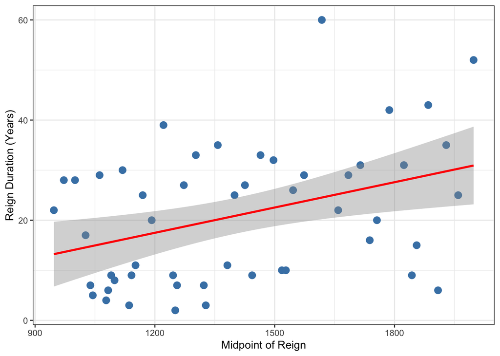

```r
kingsduration %>%
  mutate(midyear = (`Reign Start` + `Reign End`)/2) %>%  # Note backticks for names with spaces
  ggplot(aes(x = midyear, y = Duration)) +
  geom_point(color = "steelblue", size = 3) +
  geom_smooth(method = "lm", color = "red") +
  labs(x = "Midpoint of Reign", y = "Reign Duration (Years)") +
  theme_bw()
```

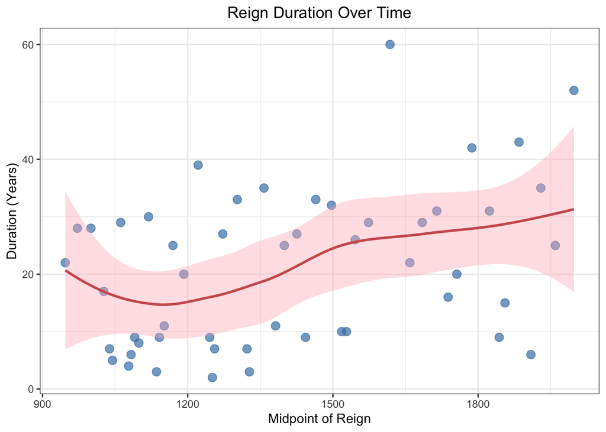

```r
kingsduration %>%
  # First verify and use correct column names
  mutate(Duration = `Reign End` - `Reign Start`,  # Use actual column names
         Midyear = `Reign Start` + Duration/2) %>%
  ggplot(aes(x = Midyear, y = Duration)) +
  geom_point(color = "steelblue", alpha = 0.7, size = 3) +
  geom_smooth(method = "loess", color = "indianred", fill = "lightpink") +
  labs(title = "Reign Duration Over Time",
       x = "Midpoint of Reign",
       y = "Duration (Years)") +
  theme_bw() +
  theme(plot.title = element_text(hjust = 0.5))
```

[output not shown]